# Bivariate Relationships Assignment

# Step 1: Determine what variables for your two main constructs you want to graph based on your research topic.

You will need a mixture of categorical and quantitative variables for this assignment.

- One association with a categorical explanatory and categorical response variable. (C ~ C)
- One association with a categorical explanatory and quantitative response variable. (Q ~ C)
- One association with a quantitative explanatory and binary categorical response variable. (B ~ Q)
- One association with a quantitative explanatory and quantitative response variable. (Q ~ Q)

If you do not have 1 or more of the combinations above you will do one of the specific types mentioned more than once.

*Recall the following definitions:*

- Explanatory variable: independent variable, covariate, goes along the x axis
- Response variable: dependent variable, outcome, goes along the y axis.
- Model definition: y ~ x
  - C: categorical
  - B: binary categorical
  - Q: quantitative numeric / continuous

# Step 2: Recode variables as needed.

If your response variable is categorical with many levels, you may want to collapse it down to fewer levels.

**It is perfectly acceptable to recode variables temporarily for exploratory purposes and not put it in your `dm_addhealth` file.**

Think of your `dm` file as containing recodes/new variable that you know you want to keep/reuse many times and/or do analysis on.

# Step 3: Create appropriate graphics

- Create one bivariate graph for each of the four combinations listed in step 1.
- You can do any combination of the 4 types of bivariate graphs for a total of 4.
  - Do as many different combinations as you can. Not just 4 graphics on one combination (i.e. C~C)

# Step 4: Calculate appropriate summary statistics

- For continuous outcomes you’ll want to describe measures such as the mean or median for each level of the categorical variable.
- For categorical outcomes you’ll want to calculate %’s of your outcome measurement across levels of your covariate.
  - i.e. proportion of males who are smokers compared to proportion of females who are smokers
  - or proportion of smokers who are male, compared to proportion of non-smokers who are male.

# Step 5: Explain the relationship or trends you see in the data.

- Place discussion of relationship below the graph it corresponds with.
- Use specific features of the graphic in your text explanation.
  - i.e. are there outliers only in one group?
  - Do the data seem clumped or clustered in one region of the scatterplot?
  - Does one combination of categorical levels (C~C) seem to hold most the data?
- Use summary statistics and also use those in your text explanation.

# Save, post, submit.

Create a nice document similar to what you did for the Univariate assignment.

Create a blog post and attach the document there. This will be for your peer review.

# Example

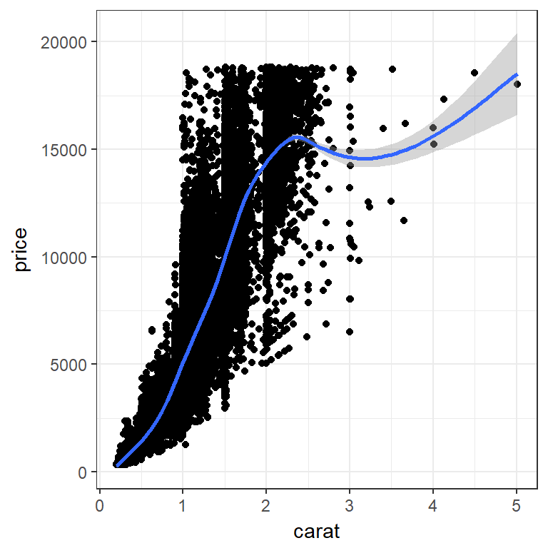

```r
library(ggplot2)
ggplot(diamonds, aes(x=carat, y=price)) + geom_point() + theme_bw() + geom_smooth()
```

```r
cor(diamonds$carat, diamonds$price)
```

```
## [1] 0.9215913
```